# swa6_Reedy_Choi_James.Rmd

Eliza Reedy, Joshua Choi, Lauren James

3/11/2021

##Q1 setup

## Q2

The gutenbergr package contains a large set of publicly-available texts. Within this package, the gutenberg_metadata object contains information about these files. Create a data frame which subsets gutenberg_metadata to retain only works by William Shakespeare. (Hint: make sure to note the way authors are represented in the metadata).

```r
shakespeare.works = filter(gutenberg_metadata, author == "Shakespeare, William")
```

## Q3

Before merging the data, we’ll do a little cleaning to make sure that the titles match in the two files. Use the tolower()command to convert all the titles in your Shakespeare subset (from Q2) to lowercase. Next, use left_join() to merge the reference file (which contains information about play type) into the data you created in Q2. Remove all texts that do not have typedata after the merge. If you’ve done this correctly, you should have a dataset with 101 rows.

## Q4

As it turns out, there are multiple versions of some texts in the data established in Q3. As a simple strategy, we’ll focus on the first text that appears if there are multiple versions. To identify this, (A) group the data by title, and use a summarize()command to find the minimum gutenberg_id(called min.id) for each title.If you’ve done this correctly, you should have a dataset with 26 rows.

```r
shakespeare.works = shakespeare.works %>% group_by(title) %>% summarize (min.id = min(gutenberg_id))
shakespeare.works
```

```
## # A tibble: 26 x 2
##    title                     min.id
##    <chr>                      <int>
##  1 a midsummer night's dream   1113
##  2 all's well that ends well   1125
##  3 antony and cleopatra        1534
##  4 as you like it              1121
##  5 coriolanus                  1797
##  6 cymbeline                   1133
##  7 hamlet                      1787
##  8 julius caesar               1522
##  9 king lear                   1794
## 10 love's labour's lost        1109
## # … with 16 more rows
```

## Q5

Use the pull()command to create a vector with the gutenberg_id values for the Shakespeare plays in the data from Q4. As an example, I’ve stored my data from Q4 in an object calledshakes.dedup, so I’ll run:1 shakes.vec = shakes.dedup %>% pull(min.id) Use the gutenberg_download()function along with this vector to create an object with the plays. (e.g.plays= gutenberg_download(shakes.vec))

```r
id.vec = pull(shakespeare.works, min.id)
plays = gutenberg_download(id.vec)
```

```
## Determining mirror for Project Gutenberg from http://www.gutenberg.org/robot/harvest
```

```
## Using mirror http://aleph.gutenberg.org
```

## Q6

To prepare for sentiment analysis, we’re going to do a bit of light cleaning. As an aside, you may notice that there’s a boilerplate at the beginning of several texts – we’ll ignore this problem in our analysis.To lightly clean the data, we’ll add the play title information to the text data, using our data from Q4. To do this, we’ll need to make sure the names of the id columns in the Q4 data and the newly-acquired play textdata match. To ensure this, shift the name of the id variable in the Q4 data using something like:

shakes.dedup = shakes.dedup %>% rename(gutenberg_id = min.id)

Next, merge in the titles using left_join()

After merging in the titles, you can use the original reference file (com_trag.csv to merge in the play types(comedy vs. tragedy)).

Do this now. If you’ve conducted the steps correctly, you should have a data framewith four columns –gutenberg_id,text,title, and type

```r
shakespeare.works = shakespeare.works %>% rename(gutenberg_id = min.id)
shakespeare.join = left_join(plays, shakespeare.works)
shakespeare.join = left_join(shakespeare.join, data)
shakespeare.join
```

```
## # A tibble: 103,169 x 4
##    gutenberg_id text                                    title         type
##           <int> <chr>                                   <chr>         <chr>
##  1         1104 **************************************… the comedy o… come…
##  2         1104 THIS EBOOK WAS ONE OF PROJECT GUTENBER… the comedy o… come…
##  3         1104 TIME WHEN PROOFING METHODS AND TOOLS W… the comedy o… come…
##  4         1104 IS AN IMPROVED EDITION OF THIS TITLE W… the comedy o… come…
##  5         1104 (#23046) at https://www.gutenberg.org/… the comedy o… come…
##  6         1104 **************************************… the comedy o… come…
##  7         1104 ""                                      the comedy o… come…
##  8         1104 ""                                      the comedy o… come…
##  9         1104 ""                                      the comedy o… come…
## 10         1104 ""                                      the comedy o… come…
## # … with 103,159 more rows
```

## Q7

Julia Silge provides reference code which unnests tokens, and establishes relative location – we’ll use a slightly modified version to create a rel.line feature, which runs 0 to 100 for all books. I called the output from Q6 plays.type– use the following code (adjusted for the name of your object in Q6) to unnest tokens and establish relative line locations:

```r
plays.cln <- shakespeare.join %>%
  mutate(counter = 1) %>%
  unnest_tokens(word, text) %>%
  group_by(title) %>%
  mutate(linenumber = cumsum(counter),
         max.lns = max(linenumber),
         rel.line = floor((linenumber / max.lns)*100))
```

## Q8

With the data cleaned, we’re ready to add in sentiment scores using the bing dataset – use the following code to do this:

```r
plays.sent <- plays.cln %>%
  inner_join(get_sentiments("bing")) %>%
  count(title, type, rel.line, sentiment) %>%
  spread(sentiment, n, fill = 0) %>%
  mutate(sentiment = positive - negative)
head(plays.sent)
```

```
## # A tibble: 6 x 6
## # Groups:   title [1]
##   title                     type   rel.line negative positive sentiment
##   <chr>                     <chr>     <dbl>    <dbl>    <dbl>     <dbl>
## 1 a midsummer night's dream comedy        0        0        6         6
## 2 a midsummer night's dream comedy        1        0        6         6
## 3 a midsummer night's dream comedy        2        1        1         0
## 4 a midsummer night's dream comedy        3        2        6         4
## 5 a midsummer night's dream comedy        4       13        4        -9
## 6 a midsummer night's dream comedy        5       11        3        -8
```

## Q9

We now have clean data that’s ready to plot! The plays.sent data has a value of sentiment for each combination of title x rel.line. Create a single plot with rel.line on the X-axis, and sentiment on theY-axis. Rather than creating a scatter plot, use a geom_smooth()to plot the (smoothed) sentiment trajectory.Use color to indicate play type (comedy vs. trajedy), and facet_wrap()to create separate plots for each title.Add a horizontal line as a reference by adding+ geom_hline(yintercept = 0, linetype = “longdash”,col = “gray”). All these steps together should create a single plot with 26 faceted plots.

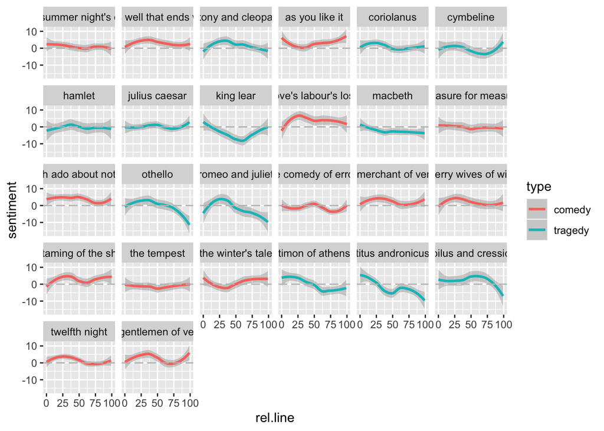

```r
ggplot(plays.sent, aes(rel.line, sentiment, col = type)) + geom_smooth() +
  facet_wrap(vars(title)) + geom_hline(yintercept = 0, linetype =
                                         "longdash",col = "gray")
```

## Q10

Provide some discussion of this plot – do you notice differences between comedies and tragedies? What jumps out to you? (aim for a short paragraph to interpret)

To look at the broader differences between comedies and tragedies, consider this graph, which is the same as above without the faceting:

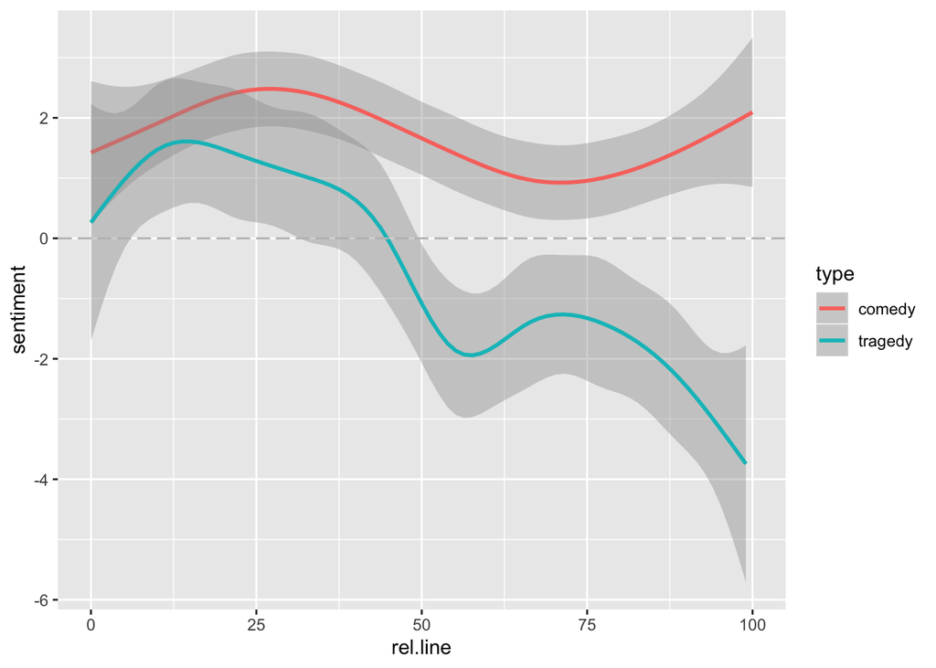

```r
ggplot(plays.sent, aes(rel.line, sentiment, col = type)) + geom_smooth() +
  geom_hline(yintercept = 0, linetype = "longdash",col = "gray")
```

The comedies on average have all positive valence. Even in the comedies, the overall trajectory of the middle portion is downward, probably representing some necessary conflict. They generally end with a positive slope.

The tragedy graph is interesting– it starts out slightly positive and getting better. I can imagine that a tragedy would be less sad if nothing good happens to begin with, as opposed to when something good happens and then falls apart. It’s also interesting that many of the tragedies have two humps, so at some point in the middle things stop getting worse for a moment, and then do again. The tragedy graph also importantly ends with a negative slope– things are still getting worse, and not better.